# SWOW-RP Descriptives

## Participants

```
   Non-native Perseveration      Underage         Valid       Verbose             X
          722           307           897         64598            15           986
```

There were 67525 participants in total (17.3% males, 81.7% females and 1% other) with an average age of 38.3 (SD = 15.1, min = 5, max = 99). Participants were excluded based on several demographic and response criteria. First, only participants aged 16 and older were retained. Next, participants responses that provided the same response to several cues in the list were excluded. Participants who indicated over 70% of words as either unknown or missing were excluded. Finally, participants who responded with over 30% of multiword phrases or where fewer than 60% of words were not in a Spanish word list were also excluded. The total number of excluded participants amounted to 4.3% of the original sample.

### Demographic details

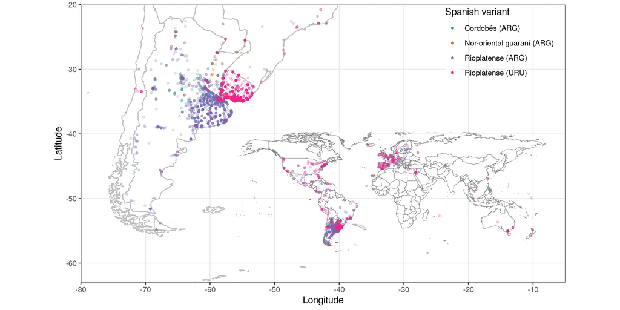

Figure 2 shows the breakdown interaction between age, gender and education.

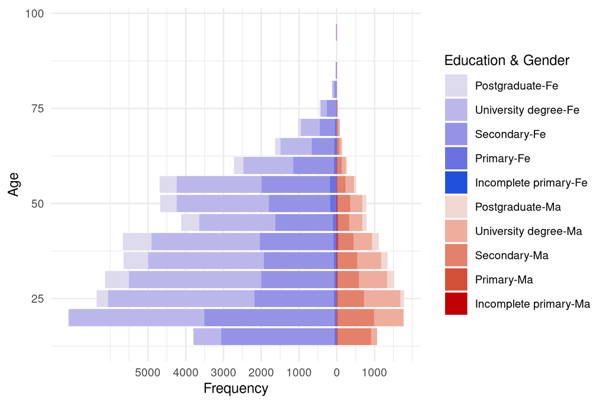

## Cues

The dataset consists of 13458 cue words and included 207 proper nouns.

## Responses

```r
file.swow = paste0('../data/SWOW/processed/SWOW-RP.spellchecked.',
                            release,'.csv')
X = read.csv(file.swow, stringsAsFactors = FALSE,encoding = 'UTF-8') %>%
  as_tibble()
nResponses = nrow(X)
```

### Missing and unknown responses

On average, 3.3 % of the cue trials were judged unknown (min = 0%, max = 60%). The 10 most unknown words are {*anatema, cisma, procrastinar, ominoso, perimido*}. Missing (i.e. “No more responses”) R2 responses occurred on average on 17% of cases. For R3, an average of 9% of cases were missing. Cues had at least 189 and at most 210 responses.

### Coverage

For each cue, the coverage was calculated as the percentage of responses that were part of the list of cue words. The average coverage for all (R123) responses was 87.2% (min = 46.4%, max = 99.3%). The top 10 words with the lowest coverage are {*unir, amabilidad, afecto, estofado, existir*}.

### Response Distribution and centrality

For each cue the entropy of the response distribution was calculated as $H(X_{cue}) = - \sum_{i=1}^n P(x_i)log_2P(x_i)$ and normalized by the information length. Cues with high entropy R123 response distributions were {*polar, símil, gélido, domicilio, Nilo*}, and cues with the lowest entropy were {*mezclas, libertad, reprimir, mala gente, vagos*}.

Central responses are responses that are given for either for a large number of cues (type frequency) or are given frequently across all cues (token frequency).

As before, all results are based on R123 responses. The top 10 most common response *types* were {*agua, comida, amor, trabajo, dolor, dinero, música, animal, vida, casa*}. These were highly similar to the most common responses *tokens*: {*amor, trabajo, vida, persona, dolor, comida, familia, tiempo, malo, miedo*}.

```r
file.swow     = paste0('../data/SWOW/processed/SWOW-RP.R70.',release,'.csv')
source('../functions/importDataFunctions.R')
response            = 'R1'
X.swow              = importDataSWOW(file.swow,response) %>% as_tibble()
under_70=X.swow %>% group_by(cue) %>% tally() %>% filter(n<70)
```

Of the 13458 cues, 308 have less than 70 responses in R1, but at least 63